# Practical Machine Learning Project

Joe Willage

October 24, 2015

## Introduction

This paper will examine Human Activity Recognition (HAR) using machine learning techniques. The data comes from a study found [here](http://groupware.les.inf.puc-rio.br/har). The Weight Lifting Exercise had six individuals lifting dumbbells in various ways. They each lifted the dumbbells the correct specified way (classe A), as well as four incorrect ways, that correspond to common mistakes (classes B - E). Data from the movements was collected with sensors on each individual’s arm, forearm, belt, and the dumbbell. Using this data, we explored various machine learning methods to predict the manner an individual performed the exercise.

## Preprocessing

Before anything else, we need to load in our training data set.

```r
training.full <- read.csv("data/pml-training.csv", na.strings = "")
```

We’ll want to do a little exploratory data analysis. Let’s take a look at the first few rows of data (Appendix, fig. 1). There appear to be a lot of NA values. We check which columns have a high percentage of NAs (fig. 2).

These are all the columns with more than 20% NAs. We see that they include variables such as kurotsis, skew, max, min, amplitude. These are all summaries of the data. In fact, if we open the training CSV file, we see these fields are only filled in where new_window is “yes”. We decide to eliminate these columns for our analysis, and only take the columns which are the raw X, Y, Z sensor measures.

So we will work with the non-summarized rows of data (`new_window == 'no'`). From these rows, we take the X, Y, and Z measurement of gyro, acceleration, and magnet for each of the four sensor points (belt, arm, dumbbell, forearm). This leaves us with 3 * 3 * 4 = 36 features + classe.

```r
cols <- grep("_[xyz]$", names(training.full), value = T)
cols <- append(cols, "classe")
training.sub <- subset(training.full, new_window == "no")
```

We also want to split our training data into two subsets, so we can perform cross-validation. We’ll save 25% of the data for testing.

```r
inTrain <- createDataPartition(y = training.sub$classe, p = .75, list = FALSE)
training <- training.sub[inTrain, cols]
testing <- training.sub[-inTrain, cols]
```

We further validate our features by checking if there are any covariates that have little variability with the nerZeroVar command. We find there are none (fig. 3).

## Method selection

The first method we try is linear discriminant analysis. This method performs classification using linear combinations of features.

```r
modelFitLda <- train(classe ~ ., data = training, method = "lda")
modelFitLda$results$Accuracy
```

```
## [1] 0.6344376
```

Linear Discriminant Analysis yields a very poor accuracy. This is not surprising, we wouldn’t expect that x-y-z sensor readings can accurately be modeled by a linear method.

Next we look at a tree based approach, using rpart.

```r
modelFitRpart <- train(classe ~ ., data = training, method = "rpart")
modelFitRpart$results$Accuracy[1]
```

```
## [1] 0.4750388
```

This gives us a worse prediction than lda, as rpart has less than 50% accuracy.

Another tree-based approach is ctree, from the party library. The difference between this and rpart is that ctree tests for the null hypothesis between predictors and the response, and branches based on which variable has the smallest p-value. Rpart, on the other hand, branches based on measures of impurity (defaults to gini).

```r
modelFitCtree <- train(classe ~ ., data = training, method = "ctree")
modelFitCtree$results
```

```
##   mincriterion  Accuracy     Kappa  AccuracySD    KappaSD
## 1         0.01 0.8093612 0.7586161 0.009929402 0.01259985
## 2         0.50 0.8093991 0.7586537 0.010005075 0.01270584
## 3         0.99 0.8000295 0.7467883 0.010834001 0.01377257
```

This is a vast improvement over rpart, but still lower accuracy then we’d like.

Next we’ll look at random forests. We choose a k-fold cross validation with 5 folds to train. We train and predict on each of the 5 folds, then average the out of bag error rate to get an idea of what the error rate will be on our test set.

```r
fitControl    <- trainControl(method = "repeatedcv", number = 5)
modelFit <- train(classe ~ ., data = training, method = "rf",
                  trControl = fitControl)
modelFit
```

```
## Random Forest
##
## 14414 samples
##    36 predictor
##     5 classes: 'A', 'B', 'C', 'D', 'E'
##
## No pre-processing
## Resampling: Cross-Validated (5 fold, repeated 1 times)
## Summary of sample sizes: 11531, 11531, 11530, 11532, 11532
## Resampling results across tuning parameters:
##
##   mtry  Accuracy   Kappa      Accuracy SD  Kappa SD
##    2    0.9836272  0.9792803  0.002586795  0.003276171
##   19    0.9785627  0.9728693  0.005110896  0.006468650
##   36    0.9735682  0.9665465  0.004884089  0.006183186
##
## Accuracy was used to select the optimal model using  the largest value.
## The final value used for the model was mtry = 2.
```

This gives us a very high accuracy, so we will continue to tune this method. We also note that the most accurate forest was built with only 2 variables selected at each split. Selecting more variables decreased the accuracy, in this case.

## Random Forest Refinement and Training

We will switch from the caret library to randomForest, which gives more robust options. We can also examine the features that contributed most to the models.

```r
head(varImp(modelFit)[[1]][order(varImp(modelFit)[[1]], decreasing = TRUE), ,
                           drop = F])
```

```
##                     Overall
## magnet_dumbbell_z 100.00000
## magnet_dumbbell_y  91.01201
## magnet_dumbbell_x  76.31626
## accel_dumbbell_y   63.64918
## accel_belt_z       63.51506
## magnet_belt_y      61.45484
```

The top three features are the magnet sensors in the dumbbell. Let’s see if we can trim down the number of features, based on the importance.

```r
cv <- rfcv(training[,-37], training[,37], cv.fold = 5)
cv$error.cv
```

```
##         36         18          9          4          2          1
## 0.01762176 0.03274594 0.05661163 0.22172887 0.38441793 0.61197447
```

So if we only include half the features (18), our error rate about doubles. This leaves us with 18 features and an error rate of 0.0327. We’ll move forward with that. We create a new df with only the 18 features and the response.

```r
features.18 <- rownames(varImp(modelFit)[[1]]
                        [order(varImp(modelFit)[[1]], decreasing = TRUE)
                        [1:18], , drop = F])
features.18 <- append(features.18, "classe")
training.18 <- training.full[inTrain, features.18]
testing.18 <- training.full[-inTrain, features.18]
```

Now we’ll call tuneRF to determine what number mtry will reduce our error.

```r
tuneRF(training.18[, -19], training.18[, 19], mtryStart = 2)
```

```
## mtry = 2  OOB error = 3.35%
## Searching left ...
## mtry = 1     OOB error = 3.95%
## -0.1780538 0.05
## Searching right ...
## mtry = 4     OOB error = 3.21%
## 0.04140787 0.05
```

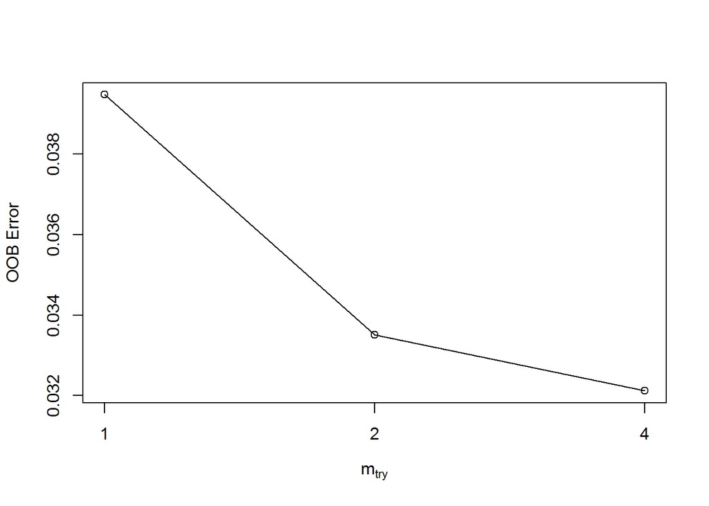

```
##       mtry   OOBError
## 1.OOB    1 0.03947551
## 2.OOB    2 0.03350909
## 4.OOB    4 0.03212155
```

The mtry with the smallest OOB error is 4, which we will pass into our randomForest call

```r
modelFitRF.18 <- randomForest(classe ~ ., data = training.18, mtry = 4)
```

Finally we fine-tune the parameters based on the outputs from our run. We see that the final OOB err rate will be around 0.0234 (fig. 4). So we’ll stop growing trees when our moving average is around that point.

```r
oob.final <- modelFitRF.18$err.rate[modelFitRF.18$ntree, 1]
nt <- modelFitRF.18$ntree
window <- 25
ntree.lower <- seq(0, nt - window, by = window)
chunks <- lapply(as.list(ntree.lower), function(x) seq(x, (x + window)))
OOB.mean <- sapply(chunks, function(x) mean(modelFitRF.18$err.rate[x, "OOB"]))
cbind(ntree.lower, ntree.lower + window, OOB.mean,
      1 - abs(1-(oob.final/OOB.mean)))
```

```
##       ntree.lower       OOB.mean
##  [1,]           0  25 0.08112794 0.2890425
##  [2,]          25  50 0.03594529 0.6523643
##  [3,]          50  75 0.02953592 0.7939290
##  [4,]          75 100 0.02725182 0.8604719
##  [5,]         100 125 0.02602971 0.9008713
##  [6,]         125 150 0.02513849 0.9328097
##  [7,]         150 175 0.02491435 0.9412017
##  [8,]         175 200 0.02494637 0.9399936
##  [9,]         200 225 0.02494370 0.9400941
## [10,]         225 250 0.02468754 0.9498487
## [11,]         250 275 0.02431130 0.9645483
## [12,]         275 300 0.02405514 0.9748197
## [13,]         300 325 0.02395107 0.9790553
## [14,]         325 350 0.02388170 0.9818994
## [15,]         350 375 0.02387636 0.9821189
## [16,]         375 400 0.02368958 0.9898626
## [17,]         400 425 0.02324129 0.9910448
## [18,]         425 450 0.02318526 0.9886063
## [19,]         450 475 0.02318526 0.9886063
## [20,]         475 500 0.02331601 0.9942779
```

The average OOB error at 375 - 400 trees gets us about 99% of the way there. We’ll rebuild our model with ntree = 400 instead of 500 (fig. 5).

```r
modelFitRF.18.375 <- randomForest(classe ~ ., data = training.18, mtry = 4,
                                  ntree = 400)
oob <- modelFitRF.18.375$err.rate[modelFitRF.18.375$ntree, 1]
```

## Testing

Now we fit the model to the testing subset of our data. The OOB estimate is generally a good proxy for out-of-sample error. That rate is 0.0245. Let’s see if the true out-of-sample error is similar. We predict on our test data, which was the 25% that we tucked away at the begining.

```r
cm <- confusionMatrix(testing.18$classe, predict(modelFitRF.18.375, testing.18[, -37]))
cm$table
```

```
##           Reference
## Prediction    A    B    C    D    E
##          A 1385    1    0    5    1
##          B   14  923   14    5    0
##          C    4   13  830    0    0
##          D    0    1   27  768    2
##          E    0    8   16    2 1189
```

We see that the model predicts with 0.9783 accuracy. This amounts to an **out of sample error** of $1 - 0.9783 * 100 = \%2.17$.

## Appendix

**Figure 1**

Seeing what the training data looks like.

```r
head(training.full)
```

```
##   X user_name raw_timestamp_part_1 raw_timestamp_part_2   cvtd_timestamp
## 1 1  carlitos           1323084231               788290 05/12/2011 11:23
## 2 2  carlitos           1323084231               808298 05/12/2011 11:23
## 3 3  carlitos           1323084231               820366 05/12/2011 11:23
## 4 4  carlitos           1323084232               120339 05/12/2011 11:23
## 5 5  carlitos           1323084232               196328 05/12/2011 11:23
## 6 6  carlitos           1323084232               304277 05/12/2011 11:23
##   new_window num_window roll_belt pitch_belt yaw_belt total_accel_belt
## 1         no         11      1.41       8.07    -94.4                3
## 2         no         11      1.41       8.07    -94.4                3
## 3         no         11      1.42       8.07    -94.4                3
## 4         no         12      1.48       8.05    -94.4                3
## 5         no         12      1.48       8.07    -94.4                3
## 6         no         12      1.45       8.06    -94.4                3
##   kurtosis_roll_belt kurtosis_picth_belt kurtosis_yaw_belt
```

[output cut: 265 more lines]

**Figure 2**

Finding out which columns have a high percentage of NAs.

```r
n <- nrow(training.full)
cols.na <- apply(training.full, 2, function(x) sum(!complete.cases(x))/n)
names(training.full)[cols.na > .20]
```

```
##  [1] "kurtosis_roll_belt"      "kurtosis_picth_belt"
##  [3] "kurtosis_yaw_belt"       "skewness_roll_belt"
##  [5] "skewness_roll_belt.1"    "skewness_yaw_belt"
##  [7] "max_yaw_belt"            "min_yaw_belt"
##  [9] "amplitude_yaw_belt"      "kurtosis_roll_arm"
## [11] "kurtosis_picth_arm"      "kurtosis_yaw_arm"
## [13] "skewness_roll_arm"       "skewness_pitch_arm"
## [15] "skewness_yaw_arm"        "kurtosis_roll_dumbbell"
## [17] "kurtosis_picth_dumbbell" "kurtosis_yaw_dumbbell"
## [19] "skewness_roll_dumbbell"  "skewness_pitch_dumbbell"
## [21] "skewness_yaw_dumbbell"   "max_yaw_dumbbell"
## [23] "min_yaw_dumbbell"        "amplitude_yaw_dumbbell"
## [25] "kurtosis_roll_forearm"   "kurtosis_picth_forearm"
## [27] "kurtosis_yaw_forearm"    "skewness_roll_forearm"
## [29] "skewness_pitch_forearm"  "skewness_yaw_forearm"
## [31] "max_yaw_forearm"         "min_yaw_forearm"
## [33] "amplitude_yaw_forearm"
```

**Figure 3**

Checking if any values have near-zero variance.

```r
nearZeroVar(training, saveMetrics = T)
```

```
##                   freqRatio percentUnique zeroVar   nzv
## gyros_belt_x       1.083754     0.9157763   FALSE FALSE
## gyros_belt_y       1.123980     0.4578882   FALSE FALSE
## gyros_belt_z       1.070872     1.1308450   FALSE FALSE
## accel_belt_x       1.095070     1.1239073   FALSE FALSE
## accel_belt_y       1.129178     0.9435271   FALSE FALSE
## accel_belt_z       1.072727     2.0119328   FALSE FALSE
## magnet_belt_x      1.011194     2.1021229   FALSE FALSE
## magnet_belt_y      1.038384     1.9772443   FALSE FALSE
## magnet_belt_z      1.017143     3.0595255   FALSE FALSE
## gyros_arm_x        1.160563     4.3846261   FALSE FALSE
## gyros_arm_y        1.471204     2.5530734   FALSE FALSE
## gyros_arm_z        1.121762     1.6234217   FALSE FALSE
## accel_arm_x        1.054264     5.2657139   FALSE FALSE
## accel_arm_y        1.095541     3.6422922   FALSE FALSE
## accel_arm_z        1.101010     5.2795893   FALSE FALSE
## magnet_arm_x       1.015385     9.1716387   FALSE FALSE
## magnet_arm_y       1.138462     5.9247953   FALSE FALSE
## magnet_arm_z       1.076923     8.6859997   FALSE FALSE
## gyros_dumbbell_x   1.033557     1.6303594   FALSE FALSE
## gyros_dumbbell_y   1.218391     1.8939920   FALSE FALSE
## gyros_dumbbell_z   1.035477     1.3667268   FALSE FALSE
## accel_dumbbell_x   1.050209     2.8097683   FALSE FALSE
## accel_dumbbell_y   1.032432     3.1566533   FALSE FALSE
## accel_dumbbell_z   1.228070     2.7681421   FALSE FALSE
## magnet_dumbbell_x  1.112000     7.4649646   FALSE FALSE
## magnet_dumbbell_y  1.215385     5.7027890   FALSE FALSE
## magnet_dumbbell_z  1.035971     4.6343832   FALSE FALSE
## gyros_forearm_x    1.025381     1.9772443   FALSE FALSE
## gyros_forearm_y    1.090580     4.9743305   FALSE FALSE
## gyros_forearm_z    1.086111     2.0049951   FALSE FALSE
## accel_forearm_x    1.179104     5.4391564   FALSE FALSE
## accel_forearm_y    1.067568     6.8613848   FALSE FALSE
## accel_forearm_z    1.000000     3.8989871   FALSE FALSE
## magnet_forearm_x   1.033333    10.1429166   FALSE FALSE
## magnet_forearm_y   1.114754    12.6613015   FALSE FALSE
## magnet_forearm_z   1.090909    11.2737616   FALSE FALSE
## classe             1.471495     0.0346885   FALSE FALSE
```

**Figure 4**

Output of first randomForest run.

```r
print(modelFitRF.18)
```

```
##
## Call:
##  randomForest(formula = classe ~ ., data = training.18, mtry = 4)
##                Type of random forest: classification
##                      Number of trees: 500
## No. of variables tried at each split: 4
##
##         OOB estimate of  error rate: 2.34%
## Confusion matrix:
##      A    B    C    D    E class.error
## A 4153   13    4   18    0 0.008357211
## B   52 2734   47    6    2 0.037662795
## C   14   47 2509    4    1 0.025631068
## D   19    3   66 2322    8 0.039702233
## E    5    6    9   14 2358 0.014214047
```

**Figure 5**

Output of final randomForest run.

```r
print(modelFitRF.18.375)
```

```
##
## Call:
##  randomForest(formula = classe ~ ., data = training.18, mtry = 4,      ntree = 400)
##                Type of random forest: classification
##                      Number of trees: 400
## No. of variables tried at each split: 4
##
##         OOB estimate of  error rate: 2.45%
## Confusion matrix:
##      A    B    C    D    E class.error
## A 4159    8    5   16    0 0.006924546
## B   57 2722   54    5    3 0.041886660
## C   17   45 2504    8    1 0.027572816
## D   22    4   68 2317    7 0.041770058
## E    5    7    7   14 2359 0.013795987
```